```python
import pandas as pd
import matplotlib.pyplot as plt
%matplotlib inline
df = pd.read_csv("tmdb-movies.csv")
len(df.columns)
```

```
21
```

```python
df.head()
```

|  | id | imdb_id | popularity | budget | revenue | original_title | cast | homepage | director | tagline | ... | overview | runtime | genres | production_companies | release_date | vote_count | vote_average | release_year | budget_adj | revenue_adj |
| --- | --- | --- | --- | --- | --- | --- | --- | --- | --- | --- | --- | --- | --- | --- | --- | --- | --- | --- | --- | --- | --- |
| 0 | 135397 | tt0369610 | 32.985763 | 150000000 | 1513528810 | Jurassic World | Chris Pratt\|Bryce Dallas Howard\|Irrfan Khan\|Vi... | http://www.jurassicworld.com/ | Colin Trevorrow | The park is open. | ... | Twenty-two years after the events of Jurassic ... | 124 | Action\|Adventure\|Science Fiction\|Thriller | Universal Studios\|Amblin Entertainment\|Legenda... | 6/9/15 | 5562 | 6.5 | 2015 | 1.379999e+08 | 1.392446e+09 |
| 1 | 76341 | tt1392190 | 28.419936 | 150000000 | 378436354 | Mad Max: Fury Road | Tom Hardy\|Charlize Theron\|Hugh Keays-Byrne\|Nic... | http://www.madmaxmovie.com/ | George Miller | What a Lovely Day. | ... | An apocalyptic story set in the furthest reach... | 120 | Action\|Adventure\|Science Fiction\|Thriller | Village Roadshow Pictures\|Kennedy Miller Produ... | 5/13/15 | 6185 | 7.1 | 2015 | 1.379999e+08 | 3.481613e+08 |
| 2 | 262500 | tt2908446 | 13.112507 | 110000000 | 295238201 | Insurgent | Shailene Woodley\|Theo James\|Kate Winslet\|Ansel... | http://www.thedivergentseries.movie/#insurgent | Robert Schwentke | One Choice Can Destroy You | ... | Beatrice Prior must confront her inner demons ... | 119 | Adventure\|Science Fiction\|Thriller | Summit Entertainment\|Mandeville Films\|Red Wago... | 3/18/15 | 2480 | 6.3 | 2015 | 1.012000e+08 | 2.716190e+08 |
| 3 | 140607 | tt2488496 | 11.173104 | 200000000 | 2068178225 | Star Wars: The Force Awakens | Harrison Ford\|Mark Hamill\|Carrie Fisher\|Adam D... | http://www.starwars.com/films/star-wars-episod... | J.J. Abrams | Every generation has a story. | ... | Thirty years after defeating the Galactic Empi... | 136 | Action\|Adventure\|Science Fiction\|Fantasy | Lucasfilm\|Truenorth Productions\|Bad Robot | 12/15/15 | 5292 | 7.5 | 2015 | 1.839999e+08 | 1.902723e+09 |
| 4 | 168259 | tt2820852 | 9.335014 | 190000000 | 1506249360 | Furious 7 | Vin Diesel\|Paul Walker\|Jason Statham\|Michelle ... | http://www.furious7.com/ | James Wan | Vengeance Hits Home | ... | Deckard Shaw seeks revenge against Dominic Tor... | 137 | Action\|Crime\|Thriller | Universal Pictures\|Original Film\|Media Rights ... | 4/1/15 | 2947 | 7.3 | 2015 | 1.747999e+08 | 1.385749e+09 |

5 rows × 21 columns

```python
df.info()
```

```
<class 'pandas.core.frame.DataFrame'>
RangeIndex: 10866 entries, 0 to 10865
Data columns (total 21 columns):
 #   Column                Non-Null Count  Dtype
---  ------                --------------  -----
 0   id                    10866 non-null  int64
 1   imdb_id               10856 non-null  object
 2   popularity            10866 non-null  float64
 3   budget                10866 non-null  int64
 4   revenue               10866 non-null  int64
 5   original_title        10866 non-null  object
 6   cast                  10790 non-null  object
 7   homepage              2936 non-null   object
 8   director              10822 non-null  object
 9   tagline               8042 non-null   object
 10  keywords              9373 non-null   object
 11  overview              10862 non-null  object
 12  runtime               10866 non-null  int64
 13  genres                10843 non-null  object
 14  production_companies  9836 non-null   object
 15  release_date          10866 non-null  object
 16  vote_count            10866 non-null  int64
 17  vote_average          10866 non-null  float64
 18  release_year          10866 non-null  int64
 19  budget_adj            10866 non-null  float64
 20  revenue_adj           10866 non-null  float64
dtypes: float64(4), int64(6), object(11)
memory usage: 1.7+ MB
```

Removed series containing Data that well not be used

```python
df.drop(["id", "imdb_id", "cast", "homepage", "tagline", "keywords", "production_companies", "director", "overview"], inplace = True, axis = 1)
```

```python
df.to_csv("check1.csv", index=False)
```

```python
df.info()
```

```
<class 'pandas.core.frame.DataFrame'>
RangeIndex: 10866 entries, 0 to 10865
Data columns (total 12 columns):
 #   Column          Non-Null Count  Dtype
---  ------          --------------  -----
 0   popularity      10866 non-null  float64
 1   budget          10866 non-null  int64
 2   revenue         10866 non-null  int64
 3   original_title  10866 non-null  object
 4   runtime         10866 non-null  int64
 5   genres          10843 non-null  object
 6   release_date    10866 non-null  object
 7   vote_count      10866 non-null  int64
 8   vote_average    10866 non-null  float64
 9   release_year    10866 non-null  int64
 10  budget_adj      10866 non-null  float64
 11  revenue_adj     10866 non-null  float64
dtypes: float64(4), int64(5), object(3)
memory usage: 1018.8+ KB
```

Converting release_date to a datetime object

```python
df["release_date"] = df["release_date"].astype("datetime64[ns]")
```

```python
df.info()
```

```
<class 'pandas.core.frame.DataFrame'>
RangeIndex: 10866 entries, 0 to 10865
Data columns (total 12 columns):
 #   Column          Non-Null Count  Dtype
---  ------          --------------  -----
 0   popularity      10866 non-null  float64
 1   budget          10866 non-null  int64
 2   revenue         10866 non-null  int64
 3   original_title  10866 non-null  object
 4   runtime         10866 non-null  int64
 5   genres          10843 non-null  object
 6   release_date    10866 non-null  datetime64[ns]
 7   vote_count      10866 non-null  int64
 8   vote_average    10866 non-null  float64
 9   release_year    10866 non-null  int64
 10  budget_adj      10866 non-null  float64
 11  revenue_adj     10866 non-null  float64
dtypes: datetime64[ns](1), float64(4), int64(5), object(2)
memory usage: 1018.8+ KB
```

Removing duplicate rows and rows with null values

```python
df.duplicated().sum()
```

```
1
```

```python
df.drop_duplicates(inplace = True)
df.duplicated().sum()
```

```
0
```

```python
df.isnull().sum()
```

```
popularity         0
budget             0
revenue            0
original_title     0
runtime            0
genres            23
release_date       0
vote_count         0
vote_average       0
release_year       0
budget_adj         0
revenue_adj        0
dtype: int64
```

Seperating the genres into different rows. This method works however it seems to be inefficient. This method was used because "|" are not constant in each row

```python
df.dropna(axis = 0, inplace = True)
df.reset_index(drop=True, inplace=True)
df1 = df.copy()
```

```python
df1["genres"]=df1["genres"].str.split("|")
df1 = df1.explode("genres").reset_index(drop=True)
df1.head()
```

|  | popularity | budget | revenue | original_title | runtime | genres | release_date | vote_count | vote_average | release_year | budget_adj | revenue_adj |
| --- | --- | --- | --- | --- | --- | --- | --- | --- | --- | --- | --- | --- |
| 0 | 32.985763 | 150000000 | 1513528810 | Jurassic World | 124 | Action | 2015-06-09 | 5562 | 6.5 | 2015 | 1.379999e+08 | 1.392446e+09 |
| 1 | 32.985763 | 150000000 | 1513528810 | Jurassic World | 124 | Adventure | 2015-06-09 | 5562 | 6.5 | 2015 | 1.379999e+08 | 1.392446e+09 |
| 2 | 32.985763 | 150000000 | 1513528810 | Jurassic World | 124 | Science Fiction | 2015-06-09 | 5562 | 6.5 | 2015 | 1.379999e+08 | 1.392446e+09 |
| 3 | 32.985763 | 150000000 | 1513528810 | Jurassic World | 124 | Thriller | 2015-06-09 | 5562 | 6.5 | 2015 | 1.379999e+08 | 1.392446e+09 |
| 4 | 28.419936 | 150000000 | 378436354 | Mad Max: Fury Road | 120 | Action | 2015-05-13 | 6185 | 7.1 | 2015 | 1.379999e+08 | 3.481613e+08 |

```python
len(df.index)
```

```
10842
```

```python
df1.to_csv("check 2.csv", index = False)
```

```python
# I have removed rows with revenue_adj smaller than 10$ (did not use mean values because there are too many invalid values)
```

```python
df2 = df[df["revenue_adj"] > 10 ]
df2
```

|  | popularity | budget | revenue | original_title | runtime | genres | release_date | vote_count | vote_average | release_year | budget_adj | revenue_adj |
| --- | --- | --- | --- | --- | --- | --- | --- | --- | --- | --- | --- | --- |
| 0 | 32.985763 | 150000000 | 1513528810 | Jurassic World | 124 | Action\|Adventure\|Science Fiction\|Thriller | 2015-06-09 | 5562 | 6.5 | 2015 | 1.379999e+08 | 1.392446e+09 |
| 1 | 28.419936 | 150000000 | 378436354 | Mad Max: Fury Road | 120 | Action\|Adventure\|Science Fiction\|Thriller | 2015-05-13 | 6185 | 7.1 | 2015 | 1.379999e+08 | 3.481613e+08 |
| 2 | 13.112507 | 110000000 | 295238201 | Insurgent | 119 | Adventure\|Science Fiction\|Thriller | 2015-03-18 | 2480 | 6.3 | 2015 | 1.012000e+08 | 2.716190e+08 |
| 3 | 11.173104 | 200000000 | 2068178225 | Star Wars: The Force Awakens | 136 | Action\|Adventure\|Science Fiction\|Fantasy | 2015-12-15 | 5292 | 7.5 | 2015 | 1.839999e+08 | 1.902723e+09 |
| 4 | 9.335014 | 190000000 | 1506249360 | Furious 7 | 137 | Action\|Crime\|Thriller | 2015-04-01 | 2947 | 7.3 | 2015 | 1.747999e+08 | 1.385749e+09 |
| ... | ... | ... | ... | ... | ... | ... | ... | ... | ... | ... | ... | ... |
| 10798 | 0.670274 | 7500000 | 33736689 | Who's Afraid of Virginia Woolf? | 131 | Drama | 2066-06-21 | 74 | 7.5 | 1966 | 5.038511e+07 | 2.266436e+08 |
| 10804 | 0.402730 | 3000000 | 13000000 | Torn Curtain | 128 | Mystery\|Thriller | 2066-07-13 | 46 | 6.3 | 1966 | 2.015404e+07 | 8.733419e+07 |
| 10805 | 0.395668 | 4653000 | 6000000 | El Dorado | 120 | Action\|Western | 2066-12-17 | 36 | 6.9 | 1966 | 3.125892e+07 | 4.030809e+07 |
| 10811 | 0.299911 | 12000000 | 20000000 | The Sand Pebbles | 182 | Action\|Adventure\|Drama\|War\|Romance | 2066-12-20 | 28 | 7.0 | 1966 | 8.061618e+07 | 1.343603e+08 |
| 10824 | 0.207257 | 5115000 | 12000000 | Fantastic Voyage | 100 | Adventure\|Science Fiction | 2066-08-24 | 42 | 6.7 | 1966 | 3.436265e+07 | 8.061618e+07 |

4840 rows × 12 columns

```python
df3 = df1[df1["revenue_adj"] > 10 ]
df3
```

|  | popularity | budget | revenue | original_title | runtime | genres | release_date | vote_count | vote_average | release_year | budget_adj | revenue_adj |
| --- | --- | --- | --- | --- | --- | --- | --- | --- | --- | --- | --- | --- |
| 0 | 32.985763 | 150000000 | 1513528810 | Jurassic World | 124 | Action | 2015-06-09 | 5562 | 6.5 | 2015 | 1.379999e+08 | 1.392446e+09 |
| 1 | 32.985763 | 150000000 | 1513528810 | Jurassic World | 124 | Adventure | 2015-06-09 | 5562 | 6.5 | 2015 | 1.379999e+08 | 1.392446e+09 |
| 2 | 32.985763 | 150000000 | 1513528810 | Jurassic World | 124 | Science Fiction | 2015-06-09 | 5562 | 6.5 | 2015 | 1.379999e+08 | 1.392446e+09 |
| 3 | 32.985763 | 150000000 | 1513528810 | Jurassic World | 124 | Thriller | 2015-06-09 | 5562 | 6.5 | 2015 | 1.379999e+08 | 1.392446e+09 |
| 4 | 28.419936 | 150000000 | 378436354 | Mad Max: Fury Road | 120 | Action | 2015-05-13 | 6185 | 7.1 | 2015 | 1.379999e+08 | 3.481613e+08 |
| ... | ... | ... | ... | ... | ... | ... | ... | ... | ... | ... | ... | ... |
| 26876 | 0.299911 | 12000000 | 20000000 | The Sand Pebbles | 182 | Drama | 2066-12-20 | 28 | 7.0 | 1966 | 8.061618e+07 | 1.343603e+08 |
| 26877 | 0.299911 | 12000000 | 20000000 | The Sand Pebbles | 182 | War | 2066-12-20 | 28 | 7.0 | 1966 | 8.061618e+07 | 1.343603e+08 |
| 26878 | 0.299911 | 12000000 | 20000000 | The Sand Pebbles | 182 | Romance | 2066-12-20 | 28 | 7.0 | 1966 | 8.061618e+07 | 1.343603e+08 |
| 26908 | 0.207257 | 5115000 | 12000000 | Fantastic Voyage | 100 | Adventure | 2066-08-24 | 42 | 6.7 | 1966 | 3.436265e+07 | 8.061618e+07 |
| 26909 | 0.207257 | 5115000 | 12000000 | Fantastic Voyage | 100 | Science Fiction | 2066-08-24 | 42 | 6.7 | 1966 | 3.436265e+07 | 8.061618e+07 |

12642 rows × 12 columns

```python
df4 = df3.query("budget_adj > 10")
df4["budget_adj"].min()
```

```
11.4477349368557
```

Finding the most repeated range for adjusted revenue

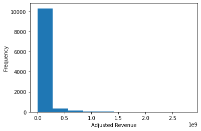

```python
df["revenue_adj"].plot(kind = "hist")
plt.xlabel("Adjusted Revenue")
```

The Graph is skewed to the right

what affects Revenues and Adjusted Revenues

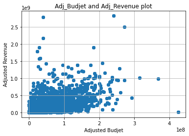

```python
plt.scatter(df4["budget_adj"], df4["revenue_adj"])
plt.xlabel("Adjusted Budjet")
plt.ylabel("Adjusted Revenue")
plt.title("Adj_Budjet and Adj_Revenue plot")
plt.grid()
```

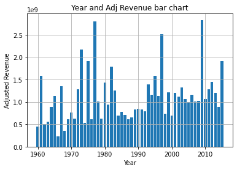

```python
plt.bar(df2["release_year"], df2["revenue_adj"])
plt.xlabel("Year")
plt.ylabel("Adjusted Revenue")
plt.title("Year and Adj Revenue bar chart")
plt.grid()
```

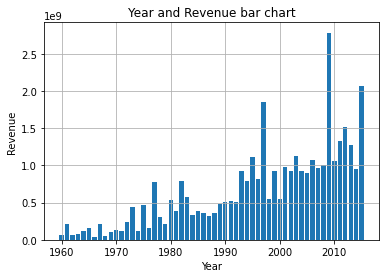

```python
plt.bar(df2["release_year"], df2["revenue"])
plt.xlabel("Year")
plt.ylabel("Revenue")
plt.title("Year and Revenue bar chart")
plt.grid()
```

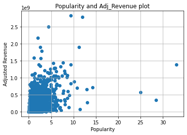

```python
plt.scatter(df2["popularity"], df2["revenue_adj"])
plt.xlabel("Popularity")
plt.ylabel("Adjusted Revenue")
plt.title("Popularity and Adj_Revenue plot")
plt.grid()
```

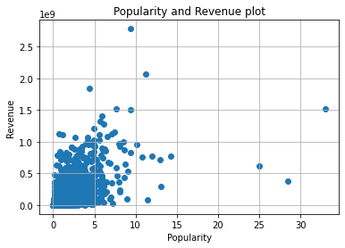

```python
plt.scatter(df2["popularity"], df2["revenue"])
plt.xlabel("Popularity")
plt.ylabel("Revenue")
plt.title("Popularity and Revenue plot")
plt.grid()
```

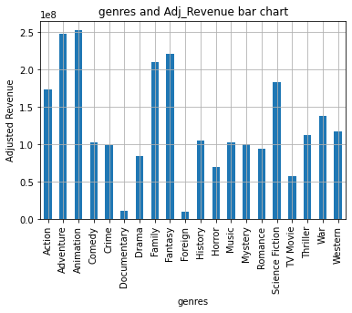

```python
groupgen = df3.groupby("genres")["revenue_adj"].mean()
groupgen.plot(kind = "bar")
plt.xlabel("genres")
plt.ylabel("Adjusted Revenue")
plt.title("genres and Adj_Revenue bar chart")
plt.grid()
```

```python
df2["month"] = df["release_date"].dt.month
grouped = df2.groupby("month")["revenue_adj"].mean()
```

```python
gropedrev = df2.groupby("month")["revenue"].mean()
```

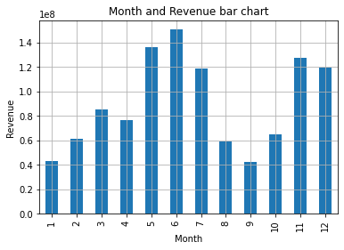

```python
gropedrev.plot(kind = "bar")
plt.xlabel("Month")
plt.ylabel("Revenue")
plt.title("Month and Revenue bar chart")
plt.grid()
```

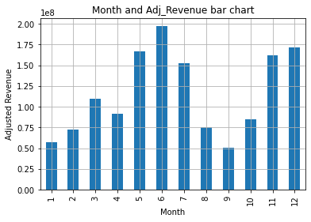

```python
grouped.plot(kind = "bar")
plt.xlabel("Month")
plt.ylabel("Adjusted Revenue")
plt.title("Month and Adj_Revenue bar chart")
plt.grid()
```

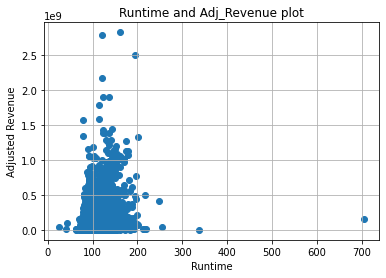

```python
plt.scatter(df2["runtime"], df2["revenue_adj"])
plt.xlabel("Runtime")
plt.ylabel("Adjusted Revenue")
plt.title("Runtime and Adj_Revenue plot")
plt.grid()
```

What affects Vote_Average

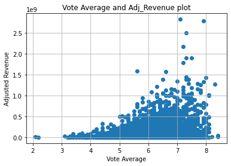

```python
plt.scatter(df2["vote_average"], df2["revenue_adj"])
plt.xlabel("Vote Average")
plt.ylabel("Adjusted Revenue")
plt.title("Vote Average and Adj_Revenue plot")
plt.grid()
```

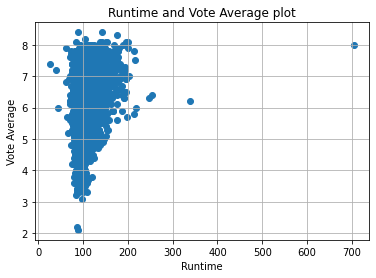

```python
plt.scatter(df2["runtime"], df2["vote_average"])
plt.xlabel("Runtime")
plt.ylabel("Vote Average")
plt.title("Runtime and Vote Average plot")
plt.grid()
```

```python
groupgen = df1.groupby("genres")["popularity"].mean()
```

Relation between Genres and popularity

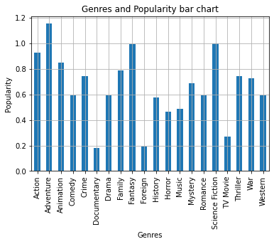

```python
groupgen.plot(kind = "bar")
plt.xlabel("Genres")
plt.ylabel("Popularity")
plt.title("Genres and Popularity bar chart")
plt.grid()
```

```python
groupgen = df1.groupby("genres")["vote_average"].mean()
```

[figure not shown]

```python
groupgen.plot(kind = "bar")
plt.xlabel("Genres")
plt.ylabel("Adjusted Revenue")
plt.title("Genres and Adj_Revenue bar chart")
plt.grid()
```

The revenue of the most of the movies are between 0 and 2.5E+8 $ (using the proce of dollars in 2010)(revenue_adj)

The revenue was at highest in recent years but that was because of reduction in the price of dollar and that was observed because the revenue_adj was at highest in 1977 and 2009 without showing a clear relation between old and recent years and the revenue_adj

Animated movies have the highest mean of revenue_adj but forigen ones have the lowest mean of revenue_adj.

There is no clear relation between popularity and revenue_adj

There is no clear relation between popularity and revenue

The data also shows that adventure movies are the most popular where the Documentry have the lowest poularity

The Documentry have the largest vote_average however the differences in vote_average between different genres are not very considerable

There is no clear relation between Runtime and the Vote Average

There is no clear relation between RunTime and Adjusted Revenue

There is no clear relation between popularity and Adjusted Revenue

Note: the revenue_adj or Adjusted revenue both means the revenue using the price of dollars in 2010